# 1. Import Libraries

```python
import pandas as pd
import matplotlib.pyplot as plt
import numpy as np
import seaborn as sns
import scipy.stats as st
%matplotlib inline
```

# 2. Reading Data into DataFrames

```python
train_df = pd.read_csv('train.csv')
train_df.info()
```

```
<class 'pandas.core.frame.DataFrame'>
RangeIndex: 1460 entries, 0 to 1459
Data columns (total 81 columns):
Id               1460 non-null int64
MSSubClass       1460 non-null int64
MSZoning         1460 non-null object
LotFrontage      1201 non-null float64
LotArea          1460 non-null int64
Street           1460 non-null object
Alley            91 non-null object
LotShape         1460 non-null object
LandContour      1460 non-null object
Utilities        1460 non-null object
LotConfig        1460 non-null object
LandSlope        1460 non-null object
Neighborhood     1460 non-null object
Condition1       1460 non-null object
Condition2       1460 non-null object
BldgType         1460 non-null object
HouseStyle       1460 non-null object
OverallQual      1460 non-null int64
OverallCond      1460 non-null int64
YearBuilt        1460 non-null int64
YearRemodAdd     1460 non-null int64
RoofStyle        1460 non-null object
RoofMatl         1460 non-null object
Exterior1st      1460 non-null object
Exterior2nd      1460 non-null object
MasVnrType       1452 non-null object
MasVnrArea       1452 non-null float64
ExterQual        1460 non-null object
ExterCond        1460 non-null object
Foundation       1460 non-null object
BsmtQual         1423 non-null object
BsmtCond         1423 non-null object
BsmtExposure     1422 non-null object
BsmtFinType1     1423 non-null object
BsmtFinSF1       1460 non-null int64
BsmtFinType2     1422 non-null object
BsmtFinSF2       1460 non-null int64
```

[output cut: 31 more lines]

```
EnclosedPorch    1460 non-null int64
3SsnPorch        1460 non-null int64
ScreenPorch      1460 non-null int64
PoolArea         1460 non-null int64
PoolQC           7 non-null object
Fence            281 non-null object
MiscFeature      54 non-null object
MiscVal          1460 non-null int64
MoSold           1460 non-null int64
YrSold           1460 non-null int64
SaleType         1460 non-null object
SaleCondition    1460 non-null object
SalePrice        1460 non-null int64
dtypes: float64(3), int64(35), object(43)
memory usage: 924.0+ KB
```

# 3. Data Analysis

## 3.1. Overview

[output not shown]

The features of the house can be broke down to: Bedroom, Bathroom, Basement, Gardening/Lot Features, House's history, Location

## 3.2. General Analysis

### 3.2.1 Missing Data Analysis

Let's dive into the amount of missing data we have on hands:

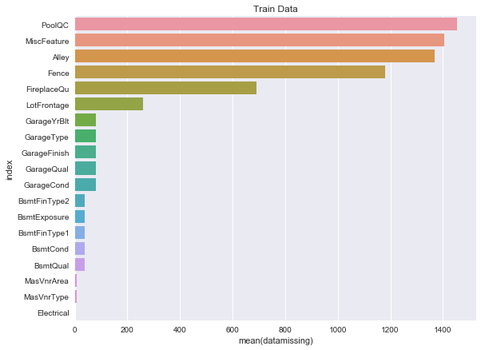

```python
missing = train_df.isnull().sum()
missing = missing[missing >0]
missing.sort_values(inplace=True, ascending=False)
missing = pd.DataFrame(missing, columns=['datamissing'])
missing.reset_index(inplace=True)
plt.figure(figsize=(9,7))
missingviz = sns.barplot(y=missing['index'], x=missing['datamissing'], orient="h")
missingviz.set_title('Train Data')
```

It is important to note that eventhough it is missing data, most of the values listed as NA because those houses did not contain those features. For example, There are missing data in Garage related features, this is due to the fact that some houses do not have Garage

Most of these nulls values will be taken care of it in the Data Cleaning part of this blog which will be up in couple weeks

### 3.2.2 Houses and SalePrice Distribution

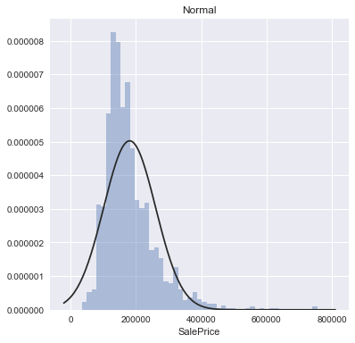

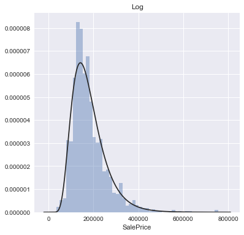

```python
plt.figure(figsize=(6, 6));plt.title('Normal')
sns.distplot(train_df.SalePrice,kde=False,fit=st.norm)
plt.figure(figsize=(6, 6));plt.title('Log')
sns.distplot(train_df.SalePrice,kde=False,fit=st.lognorm)
```

The distribution plots above showed that it is best to take log of the SalePrice which will give us a smoother and more accurate distribution

```python
train_df['SalePrice'].quantile(0.99)
```

```
442567.0100000005
```

Any Houses that are higher than the 99% of the distribution, would be candidates for outliers

```python
print 'Number of Houses that have SalePrice higher than 500k: ', train_df['SalePrice'][train_df['SalePrice']>500000].count()
```

```
Number of Houses that have SalePrice higher than 500k:  9
```

```
- These Houses potentially can be removed because these house seems to be outliers
- Lets take a look at the distribution after removing the outliers
```

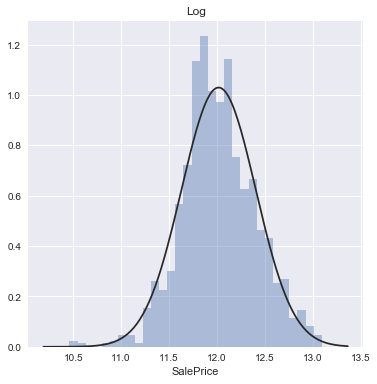

```python
no_outliers = np.log(train_df['SalePrice'][train_df['SalePrice']<500000])

plt.figure(figsize=(6, 6));plt.title('Log')
sns.distplot(no_outliers,kde=False,fit=st.norm)
```

The distribution seems to fit better with log now

We now quickly look at the rest of Sale related features mainly:

```
- SaleType
- SaleCondition
```

##### SaleType

SaleType: Type of sale

```
   WD       Warranty Deed - Conventional
   CWD      Warranty Deed - Cash
   VWD      Warranty Deed - VA Loan
   New      Home just constructed and sold
   COD      Court Officer Deed/Estate
   Con      Contract 15% Down payment regular terms
   ConLw      Contract Low Down payment and low interest
   ConLI      Contract Low Interest
   ConLD      Contract Low Down
   Oth      Other
```

```
       SaleType    Percent
WD         1267  86.780822
New         122   8.356164
COD          43   2.945205
ConLD         9   0.616438
ConLw         5   0.342466
ConLI         5   0.342466
CWD           4   0.273973
Oth           3   0.205479
Con           2   0.136986
```

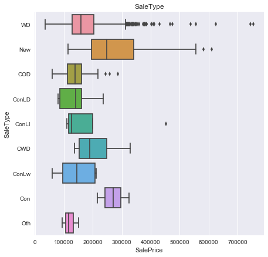

```python
SaleType = pd.DataFrame((train_df['SaleType'].value_counts()))
SaleType['Percent'] = (SaleType['SaleType']/1460)*100
print SaleType
plt.figure(figsize=(7, 7));plt.title('SaleType')
SaleTypeviz = sns.boxplot(x=train_df['SalePrice'], y= train_df['SaleType'])
```

Many houses were bought as Warranty Deed - Conventional (87%). In addition, houses were bought with Cash have a slightly higher distribution in SalePrice

##### SaleCondition:

```
SaleCondition: Condition of sale
   Normal   Normal Sale
   Abnorml  Abnormal Sale -  trade, foreclosure, short sale
   AdjLand  Adjoining Land Purchase
   Alloca   Allocation - two linked properties with separate deeds, typically condo with a garage unit
   Family   Sale between family members
   Partial  Home was not completed when last assessed (associated with New Homes)
```

```
         SaleCondition    Percent
Normal            1198  82.054795
Partial            125   8.561644
Abnorml            101   6.917808
Family              20   1.369863
Alloca              12   0.821918
AdjLand              4   0.273973
```

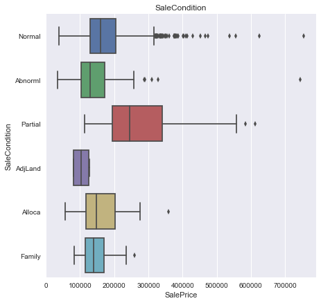

```python
SaleCondition = pd.DataFrame((train_df['SaleCondition'].value_counts()))
SaleCondition['Percent'] = (SaleCondition.SaleCondition/1460)*100
print SaleCondition
plt.figure(figsize=(7, 7));plt.title('SaleCondition')
SaleTypeviz = sns.boxplot(x=train_df['SalePrice'], y= train_df['SaleCondition'])
```

When houses were with SaleCondition of Partial, the distribution seems to be higher than other SaleConditions

##### Sale related features Conclusion:

Tasks that need to be take care of when cleaning data is:

```
- Use Log for SalePrice
- Remove outliers from SalePrice
```

### 3.2.2 Bedroom Analysis

```
We will take a look at BedroomAbvGr feature in detail
First, let's visualize how SalePrice affected by BedroomAbvGr features
```

```python
BedroomAbvGr = pd.DataFrame((train_df['BedroomAbvGr'].value_counts()))
BedroomAbvGr['Percent'] = (BedroomAbvGr.BedroomAbvGr/1460)*100
print BedroomAbvGr
```

```
   BedroomAbvGr    Percent
3           804  55.068493
2           358  24.520548
4           213  14.589041
1            50   3.424658
5            21   1.438356
6             7   0.479452
0             6   0.410959
8             1   0.068493
```

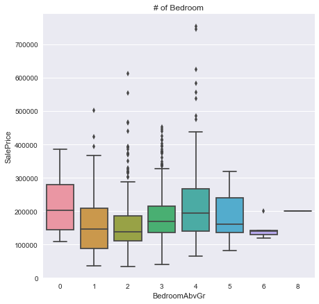

```python
plt.figure(figsize=(7, 7));plt.title('# of Bedroom')
BedroomAbvGrviz = sns.boxplot(x=train_df['BedroomAbvGr'], y= train_df['SalePrice'])
```

One unsual attribute here listed above is houses with no bedroom. How could it be? Lets investigate

```python
train_df[train_df['BedroomAbvGr']==0]
```

|  | Id | MSSubClass | MSZoning | LotFrontage | LotArea | Street | Alley | LotShape | LandContour | Utilities | ... | PoolArea | PoolQC | Fence | MiscFeature | MiscVal | MoSold | YrSold | SaleType | SaleCondition | SalePrice |
| --- | --- | --- | --- | --- | --- | --- | --- | --- | --- | --- | --- | --- | --- | --- | --- | --- | --- | --- | --- | --- | --- |
| 53 | 54 | 20 | RL | 68.0 | 50271 | Pave | NaN | IR1 | Low | AllPub | ... | 0 | NaN | NaN | NaN | 0 | 11 | 2006 | WD | Normal | 385000 |
| 189 | 190 | 120 | RL | 41.0 | 4923 | Pave | NaN | Reg | Lvl | AllPub | ... | 0 | NaN | NaN | NaN | 0 | 8 | 2008 | WD | Normal | 286000 |
| 634 | 635 | 90 | RL | 64.0 | 6979 | Pave | NaN | Reg | Lvl | AllPub | ... | 0 | NaN | GdPrv | Shed | 600 | 6 | 2010 | WD | Normal | 144000 |
| 1163 | 1164 | 90 | RL | 60.0 | 12900 | Pave | NaN | Reg | Lvl | AllPub | ... | 0 | NaN | NaN | NaN | 0 | 1 | 2008 | WD | Alloca | 108959 |
| 1213 | 1214 | 80 | RL | NaN | 10246 | Pave | NaN | IR1 | Lvl | AllPub | ... | 0 | NaN | NaN | NaN | 0 | 5 | 2006 | WD | Normal | 145000 |
| 1270 | 1271 | 40 | RL | NaN | 23595 | Pave | NaN | Reg | Low | AllPub | ... | 0 | NaN | NaN | NaN | 0 | 4 | 2010 | WD | Normal | 260000 |

6 rows × 81 columns

There are 2 possiblities here:

```
- These houses have bedrooms in the basement which the data did not account for
- They are all from Low Density Residential Area
```

### 3.2.3 Bathroom Analysis

Lets find the true total Full Bath and Half Bath which including both basement and above ground

```python
train_df['TotFullBath'] = train_df['BsmtFullBath'] + train_df['FullBath']
train_df['TotHalfBath'] = train_df['BsmtHalfBath'] + train_df['HalfBath']
```

```python
train_df['TotFullBath'].value_counts()
```

```
2    750
1    371
3    319
4     18
6      1
0      1
Name: TotFullBath, dtype: int64
```

```python
train_df['TotHalfBath'].value_counts()
```

```
0    855
1    572
2     29
3      3
4      1
Name: TotHalfBath, dtype: int64
```

```python
pd.crosstab(train_df['TotFullBath'],train_df['TotHalfBath'])
```

| TotHalfBath TotFullBath | 0 | 1 | 2 | 3 | 4 |
| --- | --- | --- | --- | --- | --- |
| 0 | 0 | 0 | 0 | 0 | 1 |
| 1 | 228 | 129 | 12 | 2 | 0 |
| 2 | 443 | 293 | 14 | 0 | 0 |
| 3 | 172 | 144 | 2 | 1 | 0 |
| 4 | 11 | 6 | 1 | 0 | 0 |
| 6 | 1 | 0 | 0 | 0 | 0 |

From the crosstab, we can see that most houses have 0 to 1 HalfBath, and 1 to 3 FullBath

How's SalePrice related to # of Bathroom

```python
train_df['Full-Half Bath'] = train_df['TotFullBath'].map(str) + '-' + train_df['TotHalfBath'].map(str)
```

```python
train_df['Full-Half Bath'].value_counts()
```

```
2-0    443
2-1    293
1-0    228
3-0    172
3-1    144
1-1    129
2-2     14
1-2     12
4-0     11
4-1      6
3-2      2
1-3      2
3-3      1
6-0      1
4-2      1
0-4      1
Name: Full-Half Bath, dtype: int64
```

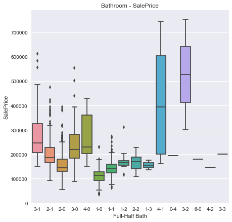

```python
plt.figure(figsize=(7, 7));plt.title('Bathroom - SalePrice')
bathroomGrviz = sns.boxplot(x=train_df['Full-Half Bath'], y= train_df['SalePrice'])
```

From the boxplot, we can see that houses with increasing amount of full bath have higher SalePrice

Conclusion for Bathroom related features:

```
- As the amount of both fullbath and halfbath increase, the saleprice also increase. However there are also exception, such as there are few houses with more than 4 bath room with a very average saleprice. These rows can consider to be outliers and can be remove.
```

### 3.2.4 Garage Analysis

```
1. Houses with Garage vs Houses with no Garage
```

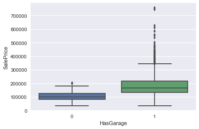

```python
train_df['HasGarage'] = train_df['GarageArea'].apply(lambda x: 1 if x>0 else 0)
sns.boxplot(x=train_df['HasGarage'], y= train_df['SalePrice'])
```

Houses with no garage have significantly lower SalePrice compare to houses with Garage

```
2. Garage Area vs SalePrice
```

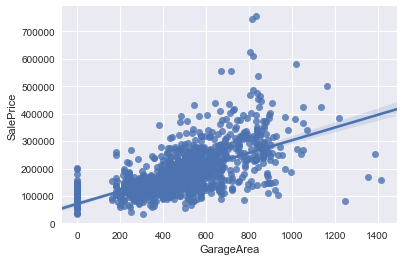

```python
sns.regplot(train_df['GarageArea'],train_df['SalePrice'])
```

If we remove some of the outliers we can see that as Garage Area increase, so will SalePrice

```
3. Garage Condition vs Garage Quality
```

```python
pd.crosstab(train_df['GarageCond'],train_df['GarageQual'])
```

| GarageQual GarageCond | Ex | Fa | Gd | Po | TA |
| --- | --- | --- | --- | --- | --- |
| Ex | 2 | 0 | 0 | 0 | 0 |
| Fa | 0 | 20 | 0 | 0 | 15 |
| Gd | 0 | 0 | 4 | 0 | 5 |
| Po | 0 | 4 | 0 | 3 | 0 |
| TA | 1 | 24 | 10 | 0 | 1291 |

Most of the Garages are with Typical/Average for both Quality and Condition

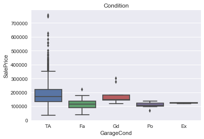

```python
sns.boxplot(x=train_df['GarageCond'], y= train_df['SalePrice']).set_title('Condition')
```

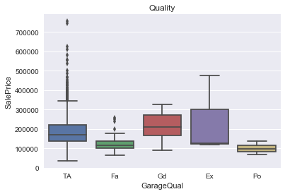

```python
sns.boxplot(x=train_df['GarageQual'], y= train_df['SalePrice']).set_title('Quality')
```

There are not enough Garage Condition or Quality that are not typical to see meaningful trend. For xxample, even with excellence condition or quality, the saleprice are not any higher compare to the least desire values (Good)

```
4. Garage Cars
```

```python
train_df['GarageCars'].value_counts()
```

```
2    824
1    369
3    181
0     81
4      5
Name: GarageCars, dtype: int64
```

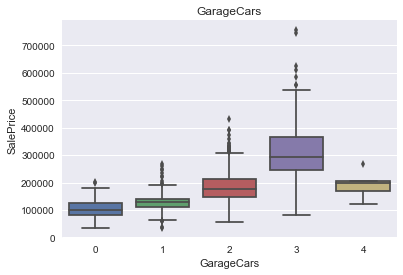

```python
sns.boxplot(x=train_df['GarageCars'], y= train_df['SalePrice']).set_title('GarageCars')
```

It is clear that the more cars can store in the garage will give u higher SalePrice, with the exception of 4 cars garage, this is due to the fact that we do not have enough data point for 4 cars to see meaningful distribution for 4 cars.

```
5. Garage Type
```

```python
train_df['GarageType'].value_counts()
```

```
Attchd     870
Detchd     387
BuiltIn     88
Basment     19
CarPort      9
2Types       6
Name: GarageType, dtype: int64
```

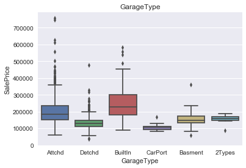

```python
sns.boxplot(x=train_df['GarageType'], y= train_df['SalePrice']).set_title('GarageType')
```

### 3.2.5 Utility and Options Analysis:

```
1. Fireplace Analysis:
```

```python
pd.crosstab(train_df['FireplaceQu'], train_df['Fireplaces'])
```

| Fireplaces FireplaceQu | 1 | 2 | 3 |
| --- | --- | --- | --- |
| Ex | 19 | 4 | 1 |
| Fa | 28 | 4 | 1 |
| Gd | 324 | 54 | 2 |
| Po | 20 | 0 | 0 |
| TA | 259 | 53 | 1 |

Most Houses have only one Fireplace

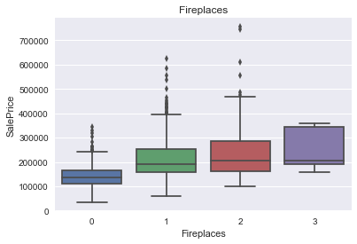

```python
sns.boxplot(x=train_df['Fireplaces'], y= train_df['SalePrice']).set_title('Fireplaces')
```

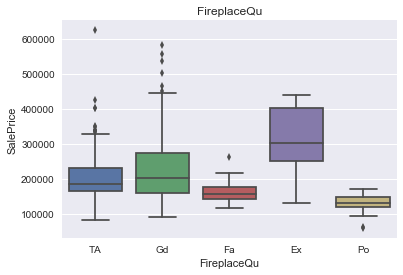

```python
sns.boxplot(x=train_df['FireplaceQu'][train_df['Fireplaces']==1], y= train_df['SalePrice']).set_title('FireplaceQu')
```

From the boxplot, you can see that the quality does matter, as the quality of the fireplace goes up, the saleprices goes up

```
2. Utilities
```

```python
train_df['Utilities'].value_counts()
```

```
AllPub    1459
NoSeWa       1
Name: Utilities, dtype: int64
```

We dont have enough variety in Data point beside AllPub. This columns is a good candidate to be dropped from the data frame

```
4. Central Air
```

```python
train_df['CentralAir'].value_counts()
```

```
Y    1365
N      95
Name: CentralAir, dtype: int64
```

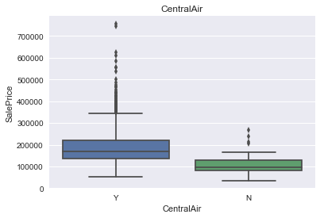

```python
sns.boxplot(x=train_df['CentralAir'], y= train_df['SalePrice']).set_title('CentralAir')
```

Houses with central air have higher Saleprice Distribution

```
5. Electrical
```

```python
train_df['Electrical'].value_counts()
```

```
SBrkr    1334
FuseA      94
FuseF      27
FuseP       3
Mix         1
Name: Electrical, dtype: int64
```

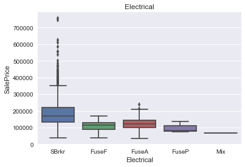

```python
sns.boxplot(x=train_df['Electrical'], y= train_df['SalePrice']).set_title('Electrical')
```

### 3.2.6 Outside of the House Features Analysis:

Some of the features that will be looked are: Alley, Fences, PavedDrive, Pool

1. Alley

Lets replace Null values to No Alley

```python
train_df.loc[train_df['Alley'].isnull(),['Alley']] = 'NoAlley'
```

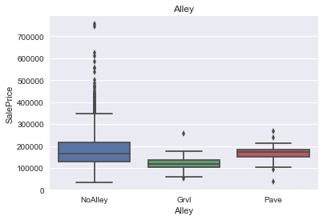

```python
sns.boxplot(x=train_df['Alley'], y= train_df['SalePrice']).set_title('Alley')
```

One thing to note that there is a different between Gravel and Pave Alley, but the distribution for No Alley is way too broad to draw any conclusion from it

```
2. Fences
```

```python
train_df['Fence'][train_df['Fence'].isnull()] = 'NoFence'
train_df['Fence'].value_counts()
```

```
NoFence    1179
MnPrv       157
GdPrv        59
GdWo         54
MnWw         11
Name: Fence, dtype: int64
```

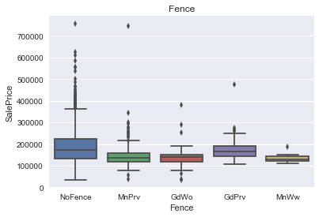

```python
sns.boxplot(x=train_df['Fence'], y= train_df['SalePrice']).set_title('Fence')
```

Convert Fences to either have Fences or Not

```python
train_df['Fence'][train_df['Fence']!= 'NoFence'] = 1
train_df['Fence'][train_df['Fence']== 'NoFence'] = 0
```

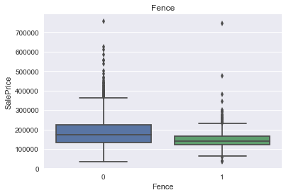

```python
sns.boxplot(x=train_df['Fence'], y= train_df['SalePrice']).set_title('Fence')
```

surprisingly, Houses with fences actually cost less than houses with no fences

```
3. Paved Drive
```

```python
train_df['PavedDrive'].value_counts()
```

```
Y    1340
N      90
P      30
Name: PavedDrive, dtype: int64
```

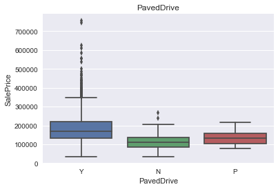

```python
sns.boxplot(x=train_df['PavedDrive'], y= train_df['SalePrice']).set_title('PavedDrive')
```

Houses with no PavedDrive seems to have lower distribution compare to the rest

```
4. Pool
```

```python
train_df['HasPool'] = train_df['PoolArea'].apply(lambda x: 1 if x>0 else 0)
```

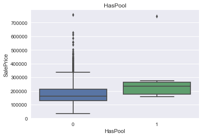

```python
sns.boxplot(x=train_df['HasPool'], y= train_df['SalePrice']).set_title('HasPool')
```

### 3.2.7 Location Features Analysis:

As many may knows, in Real Estate Location is very important. Let's us analyze location features to help gain insight on this data set

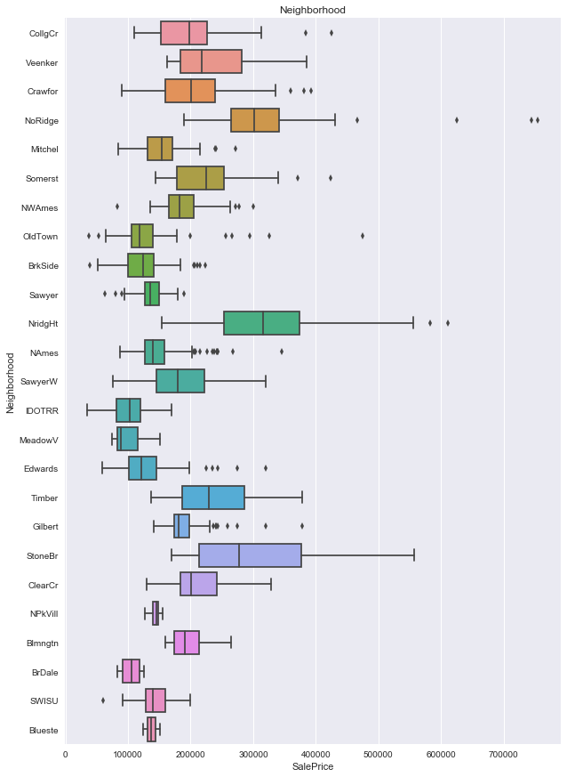

```python
plt.figure(figsize=(10,15))
a = sns.boxplot(x=train_df['SalePrice'], y= train_df['Neighborhood']).set_title('Neighborhood')
```

##### Separating catergorical and numeric variable

```python
quantitive_var = [f for f in train_df.columns if train_df.dtypes[f] != 'object']
quantitive_var.remove('SalePrice')
quantitive_var.remove('Id')
qualitative_var = [f for f in train_df.columns if train_df.dtypes[f] == 'object']
```

```python
qualitative_var.append('MSSubClass')
qualitative_var.append('OverallQual')
qualitative_var.append('OverallCond')
quantitive_var.remove('MSSubClass')
quantitive_var.remove('OverallQual')
quantitive_var.remove('OverallCond')
```

## 3.3 Categorical Variables Analysis

#### Categorical Variable

```python
#Convert qualitative data to category data
for element in qualitative_var:
    train_df[element] =  train_df[element].astype('category')
    if train_df[element].isnull().any():
        train_df[element] = train_df[element].cat.add_categories(['MISSING'])
        train_df[element] = train_df[element].fillna('MISSING')
```

The reason to convert data type of columns to category are: Performance, certain function works the way they meant to be

```python
#Determine the significant of each categorical variable based on SalePrice
def anova(frame):
    pvals = []
    anv = pd.DataFrame()
    anv['feature'] = qualitative_var
    for column in qualitative_var:
        samples =[]
        for element in frame[column].unique():
            s = frame[frame[column]==element]['SalePrice'].values
            samples.append(s)
        pval = st.f_oneway(*samples)[1]
        pvals.append(pval)
    anv['pval'] = pvals
    return anv.sort_values('pval')
```

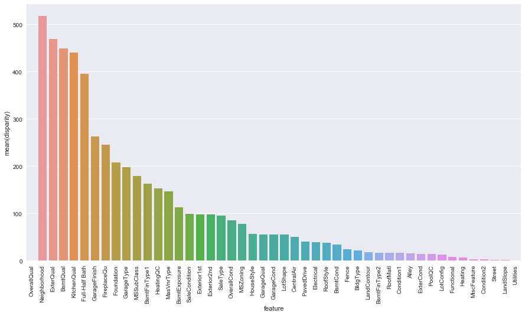

```python
a = anova(train_df)
a['disparity'] = np.log(1./a['pval'].values)
plt.figure(figsize=(15,8))
sns.barplot(data = a, x ='feature', y = 'disparity')
x = plt.xticks(rotation=90)
```

```python
#Ordering columns based on the significant
def encode(frame, feature):
    ordering = pd.DataFrame()
    ordering['val'] = frame[feature].unique()
    ordering.index = ordering.val
    ordering['spmean'] = frame[[feature, 'SalePrice']].groupby(feature).mean()['SalePrice']
    ordering = ordering.sort_values('spmean')
    ordering['ordering'] = range(1, ordering.shape[0]+1)
    ordering = ordering['ordering'].to_dict()

    for cat, o in ordering.items():
        frame.loc[frame[feature] == cat, feature+'_E'] = o

qual_encoded = []
for q in qualitative_var:
    encode(train_df, q)
    qual_encoded.append(q+'_E')
print(qual_encoded)
```

[output not shown]

```python
#Correlation
```

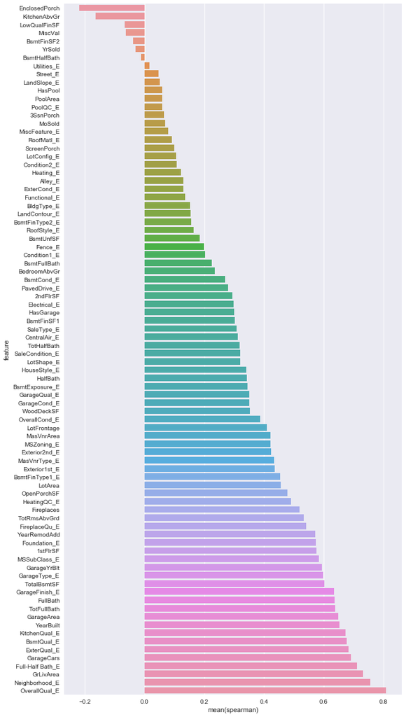

```python
def spearman(frame, features):
    spr = pd.DataFrame()
    spr['feature'] = features
    spr['spearman'] = [frame[f].corr(frame['SalePrice'], 'spearman') for f in features]
    spr = spr.sort_values('spearman')
    plt.figure(figsize=(10, 0.25*len(features)))
    sns.barplot(data = spr, x = 'spearman', y= 'feature', orient='h')
features = quantitive_var + qual_encoded
spearman(train_df, features)
```

## 3.4. Numerical Variable Analysis

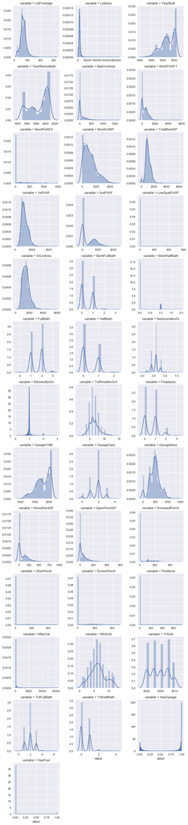

```python
f = pd.melt(train_df,value_vars= quantitive_var)
g = sns.FacetGrid(f, col='variable', col_wrap=3, sharex=False, sharey=False)
g = g.map(sns.distplot, 'value')
```

###### There are some features that are good candidates for log distribution

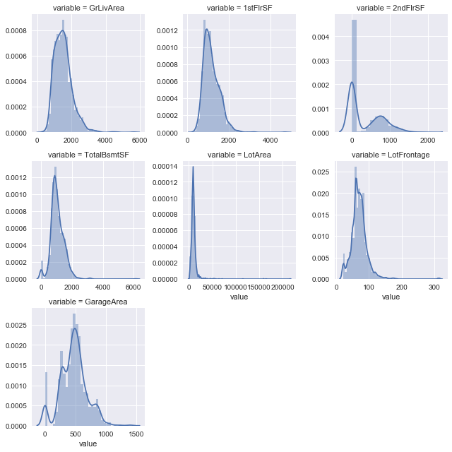

```python
#Before taking log
list1 = ['GrLivArea','1stFlrSF','2ndFlrSF','TotalBsmtSF','LotArea','LotFrontage','LotFrontage','GarageArea']

f = pd.melt(train_df,value_vars= list1)
g = sns.FacetGrid(f, col='variable', col_wrap=3, sharex=False, sharey=False)
g = g.map(sns.distplot, 'value')
```

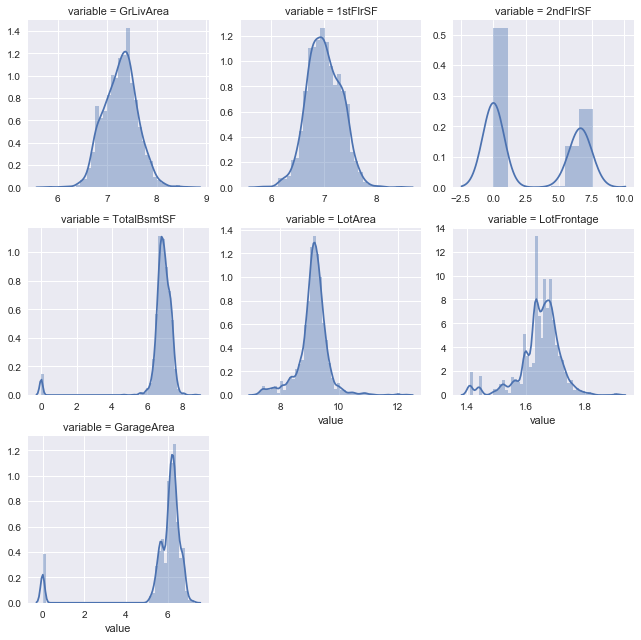

```python
#After Taking Log
train2 = train_df[list]
for i in list1:
    train2[i] = np.log1p(train2[i])

f = pd.melt(train2, value_vars= list1)
g = sns.FacetGrid(f, col='variable', col_wrap=3, sharex=False, sharey=False)
g = g.map(sns.distplot, 'value')
```

As the result of Log transformation, the distribution looks betters.

#### Correlation Matrix

```python
corr = train_df[quantitive_var + ['SalePrice']].corr()
```

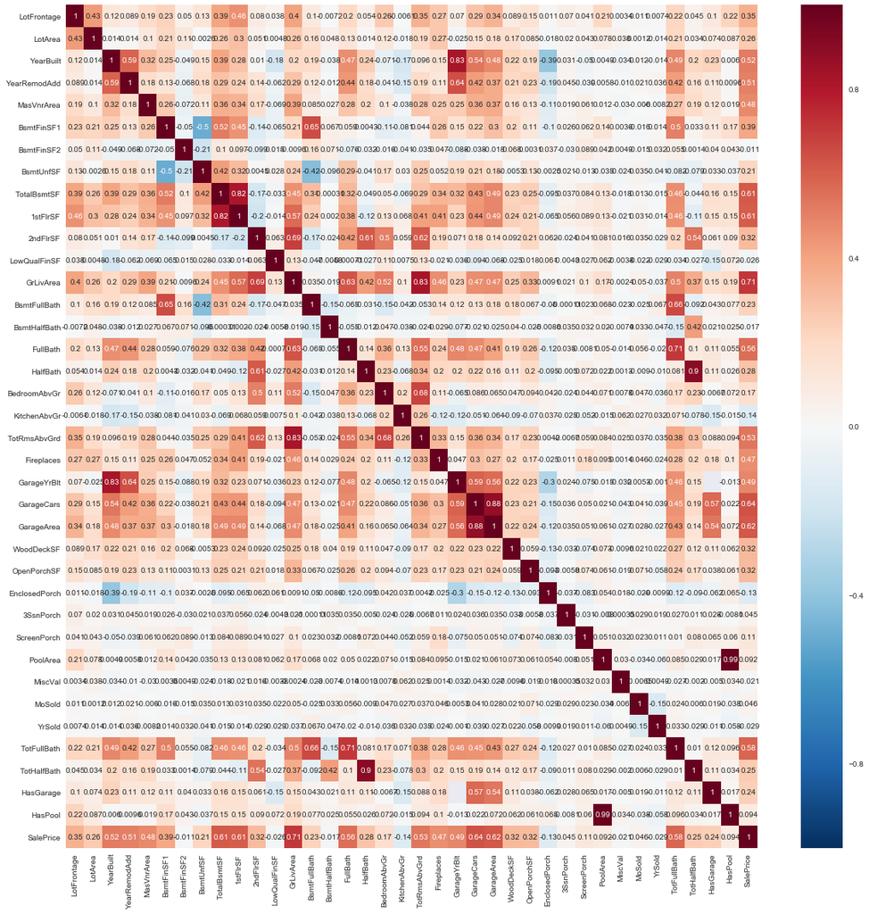

```python
plt.figure(figsize=(20,20))
sns.heatmap(corr, annot=True)
```

```python
corr['SalePrice'][corr['SalePrice']>0.2]
```

```
LotFrontage     0.351799
LotArea         0.263843
YearBuilt       0.522897
YearRemodAdd    0.507101
MasVnrArea      0.477493
BsmtFinSF1      0.386420
BsmtUnfSF       0.214479
TotalBsmtSF     0.613581
1stFlrSF        0.605852
2ndFlrSF        0.319334
GrLivArea       0.708624
BsmtFullBath    0.227122
FullBath        0.560664
HalfBath        0.284108
TotRmsAbvGrd    0.533723
Fireplaces      0.466929
GarageYrBlt     0.486362
GarageCars      0.640409
GarageArea      0.623431
WoodDeckSF      0.324413
OpenPorchSF     0.315856
TotFullBath     0.582934
TotHalfBath     0.250628
HasGarage       0.236832
SalePrice       1.000000
Name: SalePrice, dtype: float64
```

From the table above, we can see that there are some strong correlation between numerical variables and SalePrice. The next step of the project would be posted in several days.